# qPCR Analysis Report

2024-03-07

This report was generated using the ‘qPCR_report’ function from the LAB_qPCR_Data_Analysis repository.

The data follows this structure:

Genes studied:

```
## [1] "GENE1" "GENE2" "GENE3" "GENE4"
```

Conditions:

```
## [1] "KO" "WT"
```

Samples:

```
## [1] "KO1" "KO2" "WT1" "WT2" "KO3" "KO4" "WT3" "WT4"
```

## CT/DDCT values representation

CT and DDCT values are represented using boxplots and violin plots.

Boxplots represent the interquartile range (IQR) between the quartiles 1 (Q1) and 3 (Q3) of each group located in the x axis. Inside each box there is a line that represents the median of the values of that group. The whiskers show the upper and lower extremes using a 1.5*IQR.

Violin plots represent the distribution of each group using density curves. The frequency of points in areas that are wider will be higher than the narrow ones.

### CT values

#### CT values for each gene and condition

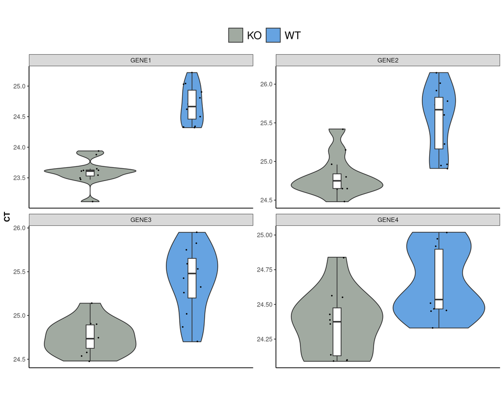

#### CT values for each gene

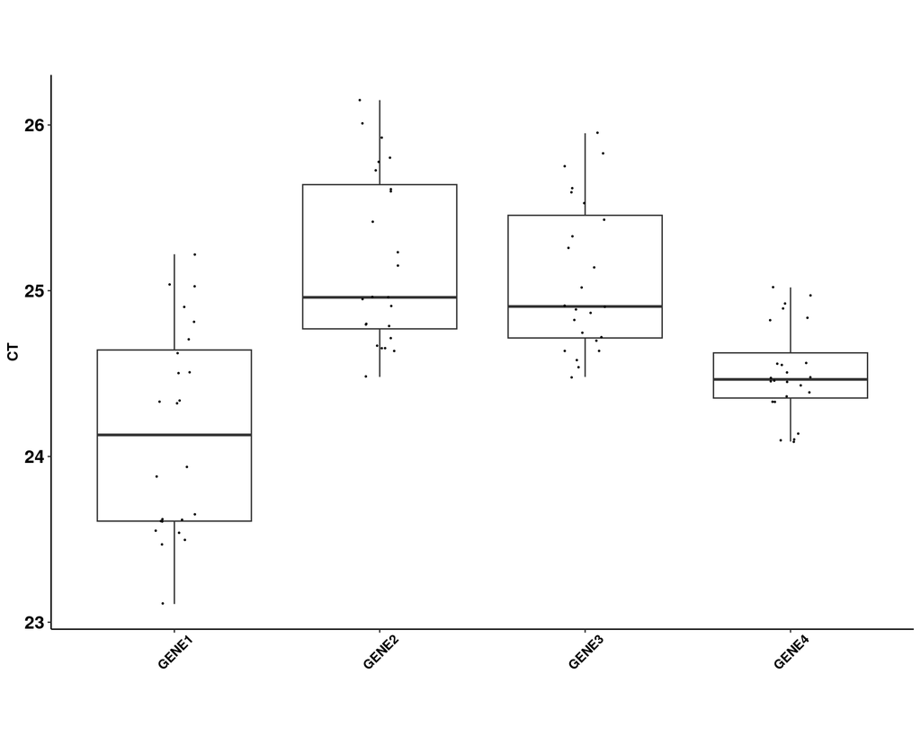

#### CT values for each condition

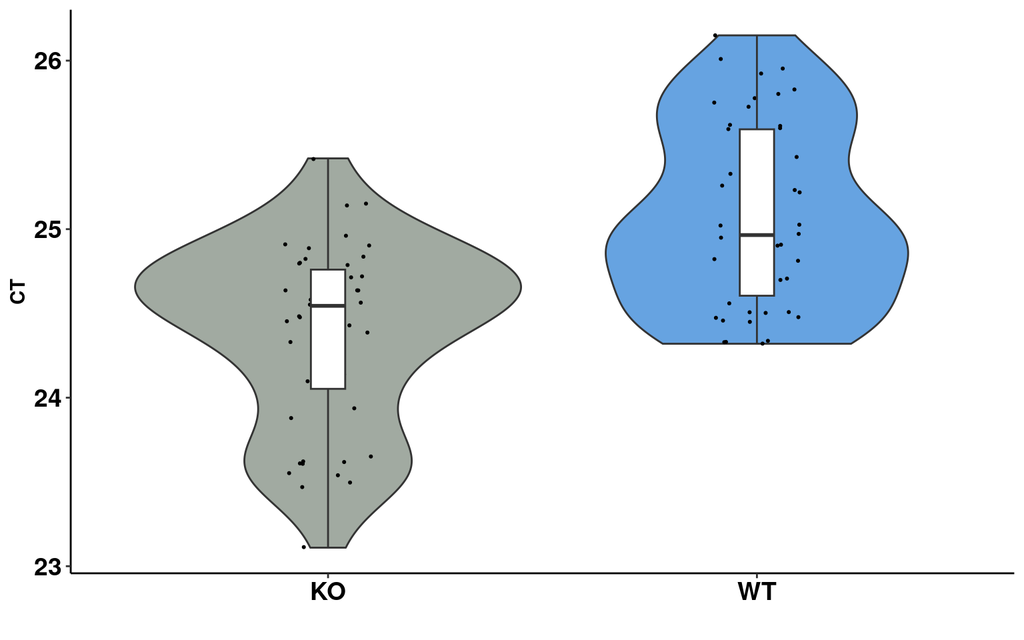

### DDCT values for each gene

```
## Mean and standard deviation were calculated for every sample and gene (due to lack of
## replicates). Therefore, a barplot is displayed. Each bar represents the mean of ddct
## (2^-(ddct)) values. The lines show the sd of each mean.
```

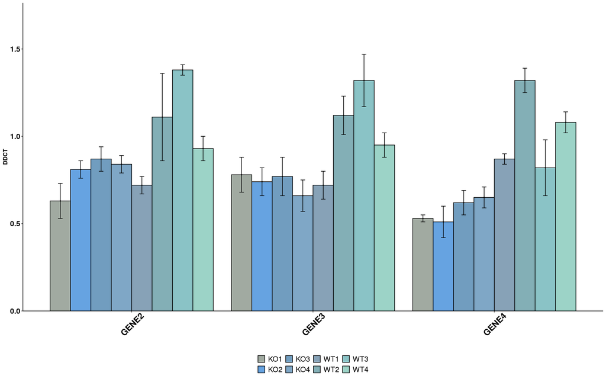

## Sample Analysis

### Principal Component Analysis

A principal component analysis was performed to the CT and DDCT data separately to reduce the dimensionality of both results. The next two plots consist in the two first components of the PCAs:

#### PCA - CT Values

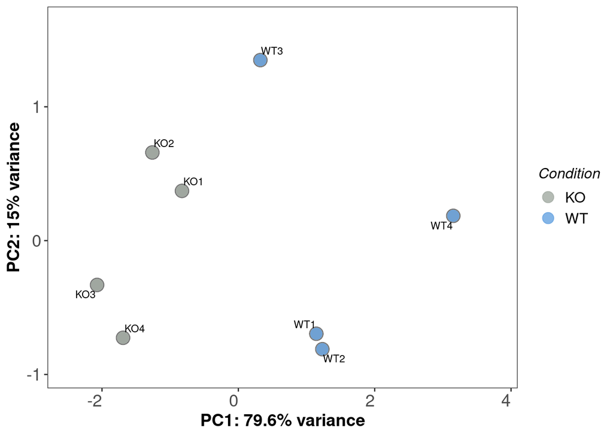

#### PCA - DDCT Values

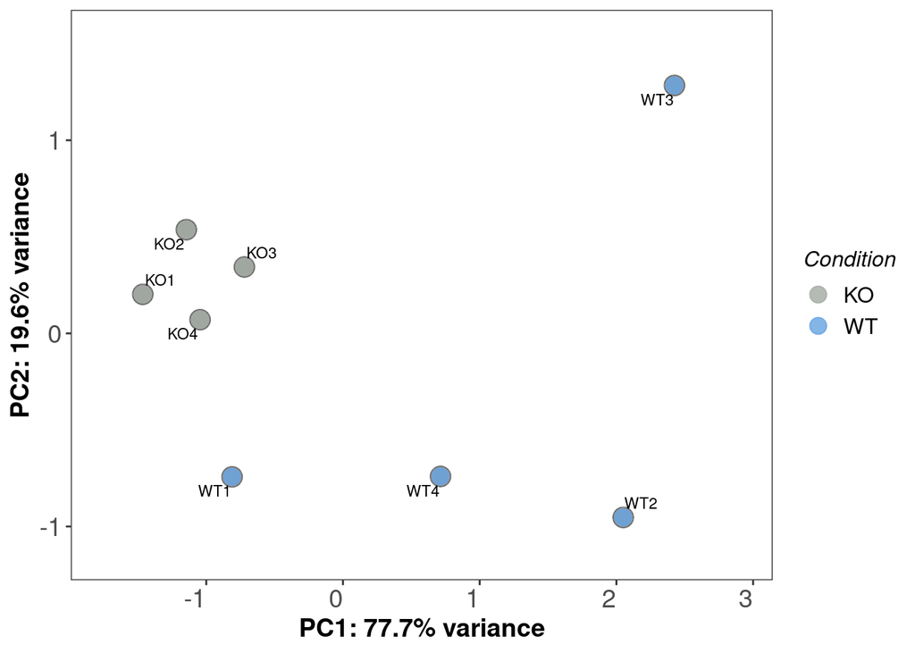

### Heatmap

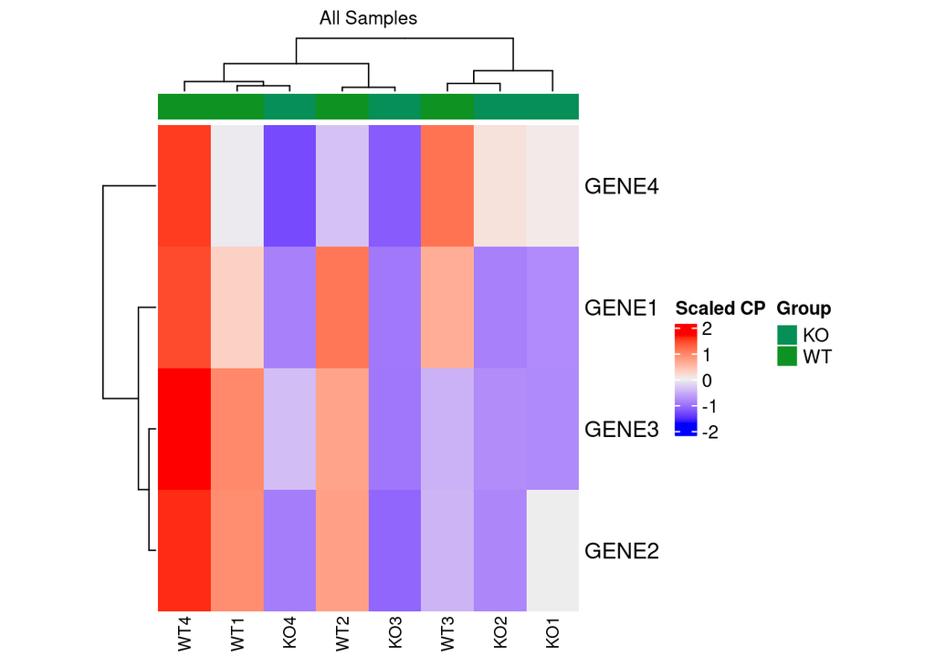

### Hierarchical clustering

The hierarchical clustering shown below uses the euclidean distance to compare the samples by similarity, using the complete method.

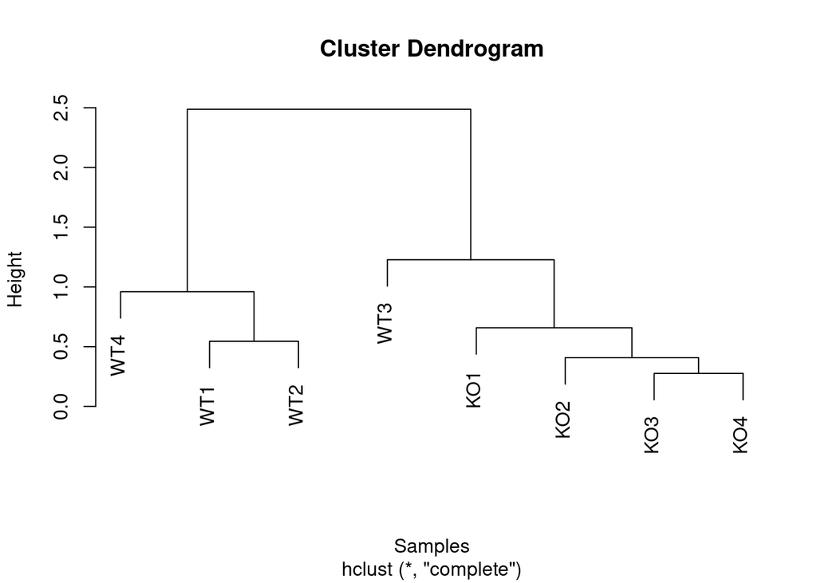

## Extreme Values Detection

To detect extreme values, z-scores were calculated for the values of each gene. These z-values are plotted below using boxplots. Each box represents the interquartile range (IQR) between the quartiles 1 (Q1) and 3 (Q3).

Inside each box there is a line that represents the median of the values of that gene.

The whiskers show the upper and lower extremes using a 1.5*IQR.

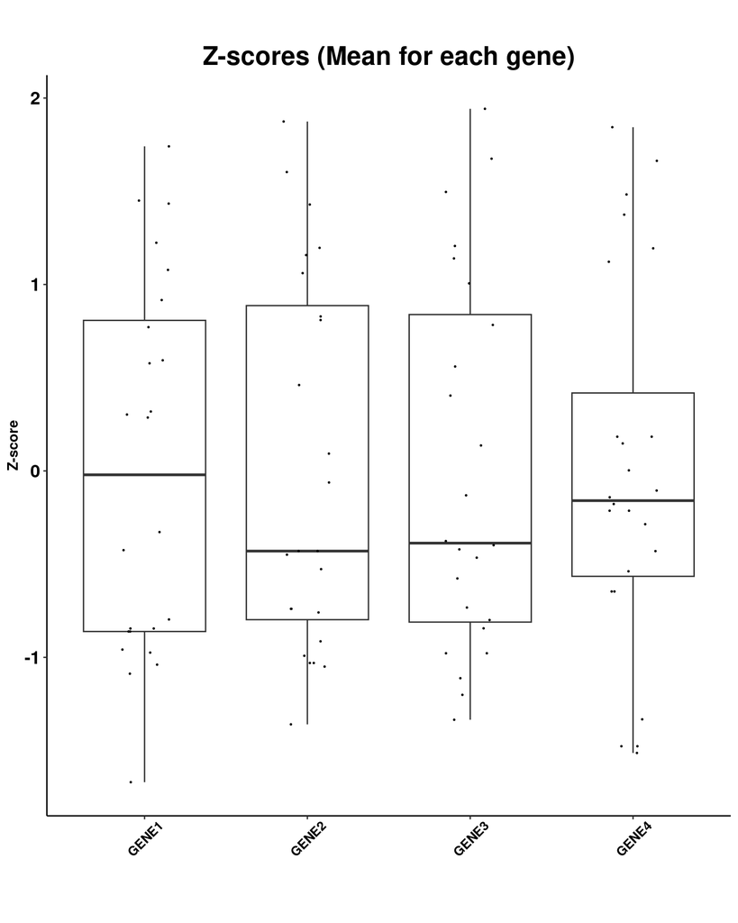

### Rosner Test

Extreme values were detected using the Rosner Test.

Rosner, B. (1975). On the Detection of Many Outliers. Technometrics, 17(2), 221â€“227. https://doi.org/10.2307/1268354.

More information available in: https://search.r-project.org/CRAN/refmans/EnvStats/html/rosnerTest.html

| i | Mean.i | SD.i | Value | Obs.Num | R.i+1 | lambda.i+1 | Outlier |
| --- | --- | --- | --- | --- | --- | --- | --- |
| 0 | 0.0000000 | 0.9840839 | 1.942301 | 71 | 1.973715 | 3.370097 | FALSE |
| 1 | -0.0204453 | 0.9685905 | 1.874200 | 47 | 1.956085 | 3.366490 | FALSE |
| 2 | -0.0406011 | 0.9535440 | 1.843737 | 92 | 1.976142 | 3.362836 | FALSE |
| 3 | -0.0608628 | 0.9381467 | 1.741007 | 24 | 1.920669 | 3.359136 | FALSE |
| 4 | -0.0804483 | 0.9239723 | 1.674782 | 72 | 1.899657 | 3.355387 | FALSE |
| 5 | -0.0997366 | 0.9102763 | 1.663274 | 95 | 1.936786 | 3.351588 | FALSE |
| 6 | -0.1193256 | 0.8958802 | 1.603115 | 46 | 1.922624 | 3.347738 | FALSE |
| 7 | -0.1386788 | 0.8818330 | 1.496436 | 70 | 1.854222 | 3.343836 | FALSE |
| 8 | -0.1572597 | 0.8691878 | 1.482810 | 94 | 1.886899 | 3.339880 | FALSE |
| 9 | -0.1761110 | 0.8559414 | 1.450053 | 22 | 1.899855 | 3.335869 | FALSE |

```
## The Rosner Test did not identify any outlier. The table below shows the most extreme values from the data:
```

|  | Gene | Group | Name | Rep | CP | z_scores |
| --- | --- | --- | --- | --- | --- | --- |
| 71 | GENE3 | WT | WT4 | 2 | 25.95 | 1.942301 |
| 47 | GENE2 | WT | WT4 | 2 | 26.15 | 1.874200 |
| 92 | GENE4 | WT | WT3 | 2 | 25.02 | 1.843737 |
| 24 | GENE1 | WT | WT4 | 3 | 25.22 | 1.741007 |
| 72 | GENE3 | WT | WT4 | 3 | 25.83 | 1.674782 |
| 95 | GENE4 | WT | WT4 | 2 | 24.97 | 1.663274 |
| 46 | GENE2 | WT | WT4 | 1 | 26.01 | 1.603115 |
| 70 | GENE3 | WT | WT4 | 1 | 25.75 | 1.496436 |
| 94 | GENE4 | WT | WT4 | 1 | 24.92 | 1.482810 |
| 22 | GENE1 | WT | WT4 | 1 | 25.04 | 1.450053 |